# Test Regularization Effects

ML

12/23/2020

You probably downloaded all files from `github("IPEM/BListener_supplementary_material")` in you current working directory

First we add some libraries, including `BListener`. Be sure that you also have `BLplot.R` in the present directory.

```r
library(reshape2)
library(tseries)
library(ggplot2)
library(gridExtra)
library(grid)
library(GGally)
### Prepare functions of BListener package an other
library(BListener)
source("./BLplot.R")
```

# Generating Figure 3

We first define the IOI-classes and then we build IOI-observed objects that fluctuate around those IOI-classes. We work with three IOIs:

- IOI1 is going from 400 to 500 milliseconds,
- IOI2 goes from 300 to 200 milliseconds, and
- IOI3 remains constant at 100 milliseconds.

Each IOI-class has 100 data points, which we then translate to the log2dur scale.

```r
lenn = 100
r1 <- seq(from=400,to=500,length.out=lenn)
r2 <- seq(from=300,to=200,length.out=lenn)
r3 <- seq(from=100,to=100,length.out=lenn)
r4 <- seq(from=100,to=100,length.out=lenn)
lr1 <- log2(r1)
lr2 <- log2(r2)
lr3 <- log2(r3)
lr4 <- log2(r4)
```

Then, random numbers are generated at each data point, using a normal distribution with zero mean and standard deviation of .15 log2dur. When these random numbers are added to the IOI-classes, one obtains the IOI-observed objects, shown as dots.

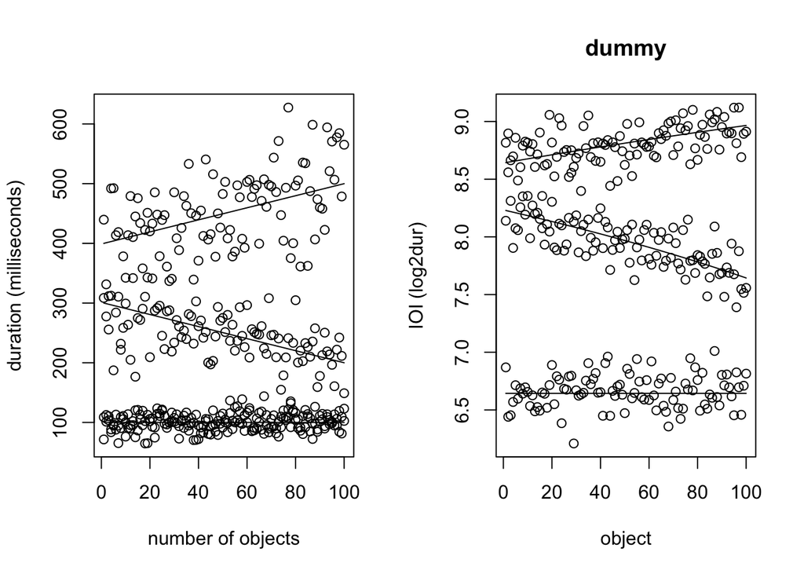

```r
set.seed(234)
rr1 = r1*0; count=1; for(v in r1){ rr1[count] <- rnorm(1,0, .15*v); count <- count+1}
rr2 = r2*0; count=1; for(v in r2){ rr2[count] <- rnorm(1,0, .15*v); count <- count+1}
rr3 = r3*0; count=1; for(v in r3){ rr3[count] <- rnorm(1,0, .15*v); count <- count+1}
rr4 = r4*0; count=1; for(v in r4){ rr4[count] <- rnorm(1,0, .15*v); count <- count+1}
lrr1 = lr1*0; count=1; for(v in lr1){ lrr1[count] <- rnorm(1,0, .15); count <- count+1}
lrr2 = lr2*0; count=1; for(v in lr2){ lrr2[count] <- rnorm(1,0, .15); count <- count+1}
lrr3 = lr3*0; count=1; for(v in lr3){ lrr3[count] <- rnorm(1,0, .15); count <- count+1}
lrr4 = lr4*0; count=1; for(v in lr4){ lrr4[count] <- rnorm(1,0, .15); count <- count+1}
par(mfrow=c(1,2))
ts.plot(cbind(r1+rr1,r2+rr2,r3+rr3,r4+rr4),
        type="p",ylab="duration (milliseconds)",xlab="number of objects")
lines(r1)
lines(r2)
lines(r3)
ts.plot(cbind(lr1+lrr1,lr2+lrr2,lr3+lrr3),
        type="p", xlab="object",ylab="IOI (log2dur)",main="dummy")
lines(lr1)
lines(lr2)
lines(lr3)
```

The next step, then, is the creation of a one-dimensional array of IOI-observed objects, by repeatedly taking values from the three IOI-classes. Finally, all values are translated to the millisecond scale.

```r
r <- cbind(lr1+lrr1,lr2+lrr2,lr3+lrr3)
r <- as.numeric(t(2^r))
u <- cumsum(r)
u <- diff(c(0,u))
head(u)
```

```
## [1] 450.77527 282.02635 116.87754 476.57363 377.32739  86.84334
```

The dataset thus simulates the situation that an ensemble plays in a meter which, while maintaining tempo, gradually shifts to another meter. Now apply `BListener`

```r
mtr = c(4,3,1)
R <- BLmain(u,mtr,tg=100,V=.000001,W=.001)
Post1 <- BLpost(R)
```

```
## [1] "Leave out the first -100 samples"
```

```r
pl1 <- BLplot(R,1)
```

```
## [1] "plot tempo = 1"
```

```r
R <- BLmain(u,mtr,tg=100,g=.1,V=.000001,W=.001)
```

```
## [1] "--------> Outlier detected, in ms: 178.600776509455"
## [1] "--------> Outlier detected, in ms: 167.714841224777"
```

```r
Post2 <- BLpost(R)
```

```
## [1] "Leave out the first -100 samples"
```

```r
pl2 <- BLplot(R,1)
```

```
## [1] "plot tempo = 1"
```

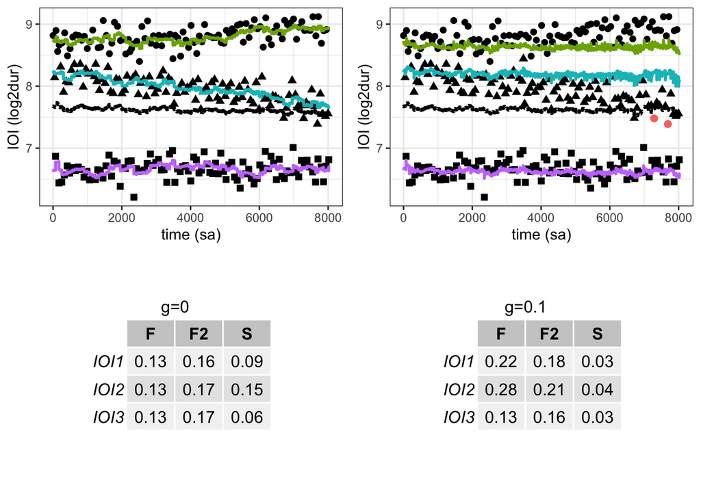

```r
#grid.arrange( pl1, pl2,ncol=2)
# Preparing and plotting the Table
F1 <- cbind(
  Post1$Fluctuation1,
  Post2$Fluctuation1)
rownames(F1) <- c("IOI1","IOI2","IOI3")
S <- cbind(
  Post1$Stability,
  Post2$Stability)
F2 <- cbind(
  Post1$Fluctuation2,
  Post2$Fluctuation2)
Mod1 <- cbind(F1[,1],F2[,1],S[,1])
colnames(Mod1) <- c("F","F2","S")
Mod2 <- cbind(F1[,2],F2[,2],S[,2])
colnames(Mod2) <- c("F","F2","S")
g1  <- tableGrob(round(Mod1,digits=2))#, cols=c("IOI1","IOI2","IOI3"))
g2  <- tableGrob(round(Mod2,digits=2))#, cols=c("IOI1","IOI2","IOI3"))
#grid.newpage()
h <- grobHeight(g1)
w <- grobWidth(g1)
title1 <- textGrob("g=0", y=unit(0.5,"npc") + h, vjust=0)#, gp=gpar(fontsize=15))
title2 <- textGrob("g=0.1", y=unit(0.5,"npc") + h, vjust=0)#, gp=gpar(fontsize=15))
gt1 <- gTree(children=gList(g1, title1))
gt2 <- gTree(children=gList(g2, title2))
# FIGURE
grid.arrange(arrangeGrob(
  pl1,
  pl2,
  gt1,gt2, ncol=2) )
```